# Course Project

## MATH2350 - Introduction to Analytics

## Semester 2, 2020

#### Daniel Ryan s3544343

#### Jingxuan Feng s3843790

#### Jahnvi Anil Tiwari s3874546

# Abstract

Micronutrients in the human body interact and are interacted with in myriad ways, and as such accurately predicting their conectrations in the body is quite difficult and prone to error.  
Analysis was run on a dataset from a previous study by Nierenberg et al. (1989), the objective being to attempt to suitably model retinol concentrations in human plasma (the target feature), and identify statistically significant predictors. After data preparation and exploration, Multiple Linear Regression was applied to generate a suitable model, which was then simplified using backwards feature selection.  
The reduced model was weak, only explaining 8.9% of variability in plasma retinol concentrations. It also tended to overestimate low observations of the target feature and underestimate high ones. As such, the final model is not assessed as a a particluarly effective predictor of plasma retinol concentrations. Despite its flaws, the model did manage to support some existing knowledge in the field and determine which features of the dataset were statistically significant, namely age, caloric intake, alcohol consumption, dietary fat and dietary fibre.

1. Source and Description
2. Objectives
3. Data Preparation
4. Data Exploration
5. Statistical Modelling and Performance Evaluation
6. Analysis and Conclusions
7. References
8. Resources

# Source and Description

Analysis in this report centres on the dataset *plasma_retinol* (sourced from OpenML (2020) and available from https://www.openml.org/d/511) which, while not officially published, formed the basis of a related study ‘Determinants of plasma levels of beta-carotene and retinol’ by Nierenberg et al. (1989).

The dataset was assembled from a cross-sectional study that took place over three years on patients who underwent elective surgery for the removal or biopsy of a benign lesion from one of multiple specified areas of the body (Stukel, T., 2001). The dataset reports three-hundred-and-fifteen observations of fourteen features which the original research team had reason to believe were related to or affected the concentrations of micronutrients in human plasma. The study measured concentrations of multiple micronutrients, however only those for retinol (a common form of vitamin A) and beta-carotene were included in the final dataset and related paper (Stukel, T., 2001).

| **Feature** | **Data type** | **Units** | **Description** |
| --- | --- | --- | --- |
| `AGE` | Discrete | Years ($y$) | Subject’s age |
| `SEX` | Nominal | 1=“Male”, 2=“Female” | Subject’s biological sex |
| `SMOKSTAT` | Ordinal | 1=“Never”, 2=“Former”, 3=“Current Smoker” | Subject’s smoking status |
| `QUETELET` | Continuous | $kgm^{-2}$ | Subject's Body Mass Index (BMI) |
| `VITUSE` | Ordinal | 1=“Yes, fairly often”, 2=“Yes, not often”, 3=“No” | Subject’s use of vitamin supplements |
| `CALORIES` | Continuous | calories ($Cal$) | Subject’s caloric intake per day |
| `FAT` | Continuous | grams ($g$) | Subject’s dietary fat intake per day |
| `FIBER` | Continuous | grams ($g$) | Subject’s dietary fibre intake per day |
| `ALCOHOL` | Continuous | unknown; most likely standard drinks | Subject’s alcohol consumption per week |
| `CHOLESTEROL` | Continuous | milligrams ($mg$) | Subject’s dietary cholesterol intake per day |
| `BETADIET` | Continuous | micrograms ($\mu g$) | Subject’s dietary beta-carotene intake per day |
| `RETDIET` | Continuous | micrograms ($\mu g$) | Subject’s dietary retinol intake per day |
| `BETAPLASMA` | Continuous | nanograms per millilitre ($ngml^{-1}$) | Subject’s plasma beta-carotene concentration |
| **`RETPLASMA`** | Continuous | nanograms per millilitre ($ngml^{-1}$) | Subject’s plasma retinol concentration |

Figure 1.1: Summary of features in the *plasma_retinol* dataset. The target feature, `RETPLASMA` is shown in bold. Source: Stukel, T. (2001)

As the dataset technically contains dual target features—`RETPLASMA` and `BETAPLASMA`—only one, `RETPLASMA` has been chosen as the focus of this report. This means that the analysis that follows will aim to explore and model concentrations of the micronutrient retinol in human plasma.

# Objectives

The objective of this report is to determine a suitable model based on Multiple Linear Regression that is able to identify signifcant predictors of and explain variability in the target feature—plasma retinol levels in humans—based on measurable biological and lifestyle factors.  
After necessary data preparation is complete, this objective will be approached by first, conducting statistical exploration of the dataset. Like all great doers of statistics, we must walk before we can run multiple linear regressions. Exploration of the dataset will enable a deeper understanding of its properties and should thus inform our decisions as we move on.  
Most importantly, Multiple Linear Regression will be employed to construct a suitable model for plasma retinol levels in human plasma. Once a suitable model has been finalised, we will analyse its suitability for our objectives and explore what it reveals about the data.

# Data Preparation

> Failing to prepare is preparing to fail.

Data preparation is an essential starting point for any statistical analysis. We begin by importing all necessary modules and reading our dataset into a Pandas dataframe called 'data'.

```python
# Import modules
import pandas as pd
import numpy as np
import scipy.stats as stats
import matplotlib.pyplot as plt
import statsmodels.api as sm
import statsmodels.formula.api as smf
import seaborn as sns
import patsy

# Some basic settings
%matplotlib inline
%config InlineBackend.figure_format = "retina"
plt.style.use("ggplot")

# Read the dataset into a Pandas dataframe 'data'
data = pd.read_csv("WorkersEquitySquad_Data.csv")
```

We are fairly fortunate that the *plasma_retinol* dataset obtained from OpenML (2020) is already very succinct. We suspect that Stukel (2001) performed some data cleaning before publishing the set. (Therese, if you're reading this, thank you.)

Let's take a quick look at the dataset to confirm it has been read in correctly and get better oriented with it. This will help inform our data preparation decisions.

```python
# Describe the shape of the dataframe
print(f"The dataset contains {data.shape[0]} observations and {data.shape[1]} features.\n")

#Preview the dataframe
data[10:15]
```

```
The dataset contains 315 observations and 14 features.
```

|  | AGE | SEX | SMOKSTAT | QUETELET | VITUSE | CALORIES | FAT | FIBER | ALCOHOL | CHOLESTEROL | BETADIET | RETDIET | BETAPLASMA | RETPLASMA |
| --- | --- | --- | --- | --- | --- | --- | --- | --- | --- | --- | --- | --- | --- | --- |
| 10 | 66 | Female | Former | 20.94647 | Yes_fairly_often | 1460.8 | 58.0 | 18.2 | 1.0 | 137.4 | 1714 | 535 | 184 | 935 |
| 11 | 40 | Female | Never | 36.43161 | Yes_not_often | 1638.2 | 49.3 | 14.9 | 0.0 | 130.7 | 2031 | 492 | 91 | 741 |
| 12 | 57 | Male | Never | 31.73039 | No | 2072.9 | 106.7 | 9.6 | 0.9 | 420.0 | 1982 | 1105 | 120 | 679 |
| 13 | 66 | Female | Never | 21.78854 | Yes_fairly_often | 987.5 | 35.6 | 10.3 | 0.0 | 254.9 | 2120 | 1047 | 61 | 507 |
| 14 | 66 | Male | Never | 27.31916 | No | 1574.3 | 75.0 | 7.1 | 0.0 | 361.5 | 1388 | 980 | 108 | 852 |

### Features

**Identifiers:** We first check the dataset for any features that act as unique observation (or row) identifiers. From a Machine Learning perspective, these are meaningless and must be excluded at the outset. It can be seen from the preview above that the dataset does not contain any features that act as unique identifiers for each observation.  
Note that the row numbers on the left are displayed by the Pandas module for ease of reference—they are not a feature of the dataset.

**Constance:** We are also concerned with ensuring that no features display a constant value. This can be seen by inspection, but for the sake of being thorough and to establish a method for use on future projects, a simple iterative block can confirm this.

```python
# Determine if any features of the dataframe have constant value across all observations
constant = []
for feature in data.columns:
    if data[feature].nunique() == 1:
        constant.append(feature)

if len(constant) > 0:
    print("The dataframe contains constant features.")
    for item in constant:
        print(f"{item} is constant.")
else:
    print("The dataframe does not contain any constant features.")
```

```
The dataframe does not contain any constant features.
```

**Relevance:** As mentioned earlier, the dataset technically has dual target features—`RETPLASMA` and `BETAPLASMA`—with `RETPLASMA` having been selected as the target of this report. As such, we remove the `BETAPLASMA` feature from the dataframe, as we do not wish to include it as a predictor for the target feature of retinol concentrations in plasma `RETPLASMA`.

The natural question now is whether or not it makes sense to include the feature `BETADIET` in our model. With limited medical knowledge it would be remiss of us to simply drop the feature because we presume that dietary beta-carotene intake has no effect on levels of other micronutrients—specifically retinol—in plasma.  
To determine at least rudimentarily if this is a reasonable presumption, a brief look at the relationship between `BETADIET` and target feature `RETPLASMA` is warranted.

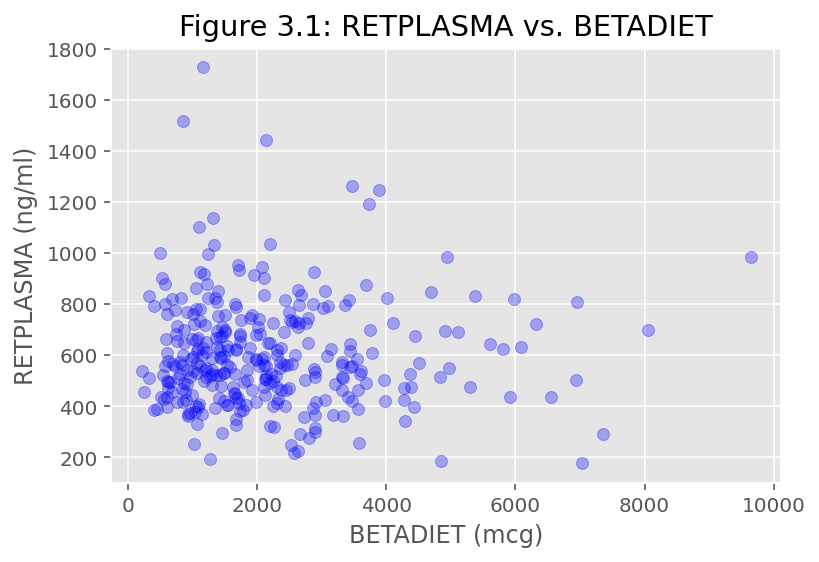

```python
# Produce a scatter plot of RETPLASMA vs. BETADIET
plt.scatter(data["BETADIET"], data["RETPLASMA"], c = "blue", alpha = 0.3)
plt.xlabel("BETADIET (mcg)")
plt.ylabel("RETPLASMA (ng/ml)")
plt.title("Figure 3.1: RETPLASMA vs. BETADIET")
```

The scatter plot in Figure 3.1 shows no particularly obvious relationship. Let's follow this up by analysing a simple linear regression of the two features as well.

```python
# Generate and summarise a simple linear regression for RETPLASMA and BETADIET
formula_string = "RETPLASMA ~ BETADIET"

model = sm.formula.ols(formula = formula_string, data = data)
model_fitted = model.fit()

print(model_fitted.summary())
```

```
                            OLS Regression Results
==============================================================================
Dep. Variable:              RETPLASMA   R-squared:                       0.000
Model:                            OLS   Adj. R-squared:                 -0.003
Method:                 Least Squares   F-statistic:                   0.05739
Date:                Sat, 31 Oct 2020   Prob (F-statistic):              0.811
Time:                        23:01:38   Log-Likelihood:                -2129.1
No. Observations:                 315   AIC:                             4262.
Df Residuals:                     313   BIC:                             4270.
Df Model:                           1
Covariance Type:            nonrobust
==============================================================================
                 coef    std err          t      P>|t|      [0.025      0.975]
------------------------------------------------------------------------------
Intercept    606.9846     21.106     28.759      0.000     565.457     648.512
BETADIET      -0.0019      0.008     -0.240      0.811      -0.018       0.014
==============================================================================
Omnibus:                       93.365   Durbin-Watson:                   1.605
Prob(Omnibus):                  0.000   Jarque-Bera (JB):              291.193
Skew:                           1.310   Prob(JB):                     5.86e-64
Kurtosis:                       6.914   Cond. No.                     4.72e+03
==============================================================================

Warnings:
[1] Standard Errors assume that the covariance matrix of the errors is correctly specified.
[2] The condition number is large, 4.72e+03. This might indicate that there are
strong multicollinearity or other numerical problems.
```

The very weak gradient (-0.0019) represented by the `BETADIET` coefficient does not indicate a relationship. The second key property here is the model's $R^2$ value. An $R^2$ of 0.00 indicates that none of the variablity in `RETPLASMA` is explained by variablity in `BETADIET`. As if that weren't enough, we note a very high p-value of 0.811 as well. Granted we have only attempted to establish a linear relationship, but for our purposes, this is sufficient evidence that the `BETADIET` feature can't reasonably be expected to be a predictor of our target feature `RETPLASMA`, and so we also remove the `BETADIET` feature from our dataframe.

```python
# Remove the BETAPLASMA and BETADIET features from the dataframe
data = data.drop(columns=["BETADIET", "BETAPLASMA"])

# Preview the modified dataframe
data.head(2)
```

|  | AGE | SEX | SMOKSTAT | QUETELET | VITUSE | CALORIES | FAT | FIBER | ALCOHOL | CHOLESTEROL | RETDIET | RETPLASMA |
| --- | --- | --- | --- | --- | --- | --- | --- | --- | --- | --- | --- | --- |
| 0 | 64 | Female | Former | 21.48380 | Yes_fairly_often | 1298.8 | 57.0 | 6.3 | 0.0 | 170.3 | 890 | 915 |
| 1 | 76 | Female | Never | 23.87631 | Yes_fairly_often | 1032.5 | 50.1 | 15.8 | 0.0 | 75.8 | 451 | 727 |

At this point, we have no reason to believe that any other feature is not relevant—at least with our limited medical knowledge, all of the remaining features could reasonably be expected to be able to affect plasma retinol concentrations.

**Redundancy:** Lastly we check for redundant features, that is, any features that have overlapping or equivalent meaning to another. Again, simple inspection is enough for us to determine that there are no cut-and-dry redundant features in the dataset.  
We suspect that there will be some collinearity between 'dietary' features, however this alone is not grounds to exclude any of them, as any individual feature might have some effect on the target feature that we as laymen (and women) do not understand.

### Missing Values

The source of the dataset OpenML (2020) reports that the set contains no missing values, however it would be remiss of us not to check. A simple block featuring nested loops can tell us whether the set contains missing values that need to be handled.

```python
# Determine if the dataframe contains missing values
missing = False
for feature in data:
    for observation in feature:
        # We define missing values as None types, empty strings, or the NumPy type NaN
        if observation is None or observation == '' or observation == np.NaN:
            missing = True
if missing == True:
    print("The dataframe contains missing values.")
else:
    print("The dataframe does not contain any missing values.")
```

```
The dataframe does not contain any missing values.
```

### Irregular Cardinality

At first glance the dataset doesn't appear to suffer any irregular cardinality of its categorical features, but we can confirm this by inspection of the unique values present for each.

```python
# Identify categorical features
print("Categorical features: SEX, SMOKSTAT, VITUSE\n")

#Describe these features in terms of their unique values
categorical_features = ["SEX","SMOKSTAT","VITUSE"]
for feature in categorical_features:
    print(f"Feature: {feature}")
    print(f"{data[feature].nunique()} unique values: {data[feature].unique()}\n")
```

```
Categorical features: SEX, SMOKSTAT, VITUSE

Feature: SEX
2 unique values: ['Female' 'Male']

Feature: SMOKSTAT
3 unique values: ['Former' 'Never' 'Current_Smoker']

Feature: VITUSE
3 unique values: ['Yes_fairly_often' 'Yes_not_often' 'No']
```

Inspection shows that irregular cardinality is not an issue for this dataset, as each unique value for a categorical feature clearly has a unique meaning.

### Outliers

Outliers have the potential to wreak havoc on a model if left unchecked.  
As such, numerical outliers will be identified using Tukey's (1977) fences; defining outliers as any values less than $Q_1 - 1.5\times IQR$ or greater than $Q_3 + 1.5\times IQR$.  
Outliers will then be Winsorised (Tukey, 1961)—put through a simple clamping transformation to reassign them the closest non-suspect value.

Before we identify and handle outliers, it is apparent that `AGE` is a feature where some *slight* outliers may still represent valid data, so let us determine if it is prudent to apply the same treatment to the `AGE` feature. Handling of slight outliers may not be warranted.

```python
#Assemble a summary of relevant descriptive stats of the AGE feature
min = data["AGE"].min()
max = data["AGE"].max()
print(f"The minimum age is {min} and the maximum age is {max} years.")
Q1 = data["AGE"].quantile(0.25)
Q3 = data["AGE"].quantile(0.75)
IQR = Q3 - Q1
upper = Q3 + 1.5*IQR
lower = Q1 - 1.5*IQR
print(f"The lower outlier threshold is {lower} and the upper outlier threshold is {upper} years.")
```

```
The minimum age is 19 and the maximum age is 83 years.
The lower outlier threshold is 3.75 and the upper outlier threshold is 97.75 years.
```

Even though our dataset doesn't contain any, we can see that it might be possible that values lying outside our thresholds are still valid ages. If hypothetically our dataset did contain reasonable age values that fell outside the thresholds calculated, it might be reasonable to apply a slightly different clamping transformation.  
We now apply an implementation of our outlier handling algorithm to the remaining numerical features.

```python
#Identify and handle outliers in numerical features
numerical_features = ["QUETELET","CALORIES","FAT","FIBER","ALCOHOL","CHOLESTEROL","RETDIET","RETPLASMA"]

# Iterate through features
for feature in numerical_features:
    counth = 0
    countl = 0
    Q1 = data[feature].quantile(0.25)
    Q3 = data[feature].quantile(0.75)
    IQR = Q3 - Q1
    upper = Q3 + 1.5*IQR
    lower = Q1 - 1.5*IQR
    # Iterate through observations of the current feature
    for i in range (0, data.shape[0]-1):
        if data.at[i, feature] > upper:    # Clamp high outliers
            data.at[i, feature] = upper
            counth += 1
        elif data.at[i, feature] < lower:    #Clamp low outliers
            data.at[i, feature] = lower
            countl += 1
        else:
            pass
    # Provide some feedback on the process
    if counth > 0 and countl > 0:
        print(f"{feature}: clamped {counth} high and {countl} low outliers.")
    elif counth > 0:
        print(f"{feature}: clamped {counth} high outliers.")
    elif countl > 0:
        print(f"{feature}: clamped {countl} low outliers.")
    else:
        print(f"{feature}: no outliers identified.")
```

```
QUETELET: clamped 15 high outliers.
CALORIES: clamped 8 high outliers.
FAT: clamped 10 high outliers.
FIBER: clamped 8 high outliers.
ALCOHOL: clamped 30 high outliers.
CHOLESTEROL: clamped 9 high outliers.
RETDIET: clamped 8 high outliers.
RETPLASMA: clamped 8 high outliers.
```

We can now progress, satisfied that we have handled any outliers in the *plasma_retinol* dataset.

# Data Exploration

[figure not shown]

> "The 95% confidence interval suggests Rexthor's dog could also be a cat, or possibly a teapot." Source: Munroe (2016)

### Exploration of Categorical Features

As always we start small, generating some visualisations relating to the basic features `AGE` and `SEX`.

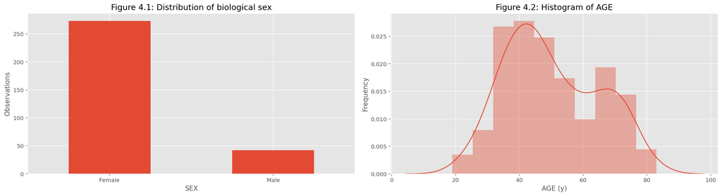

```python
# Set up the plot grid
plt.subplots(1,2, figsize=(18,5))

#Generate a barchart for SEX
plt.subplot(1,2,1)
barchart1 = data["SEX"].value_counts().plot(kind="bar")
barchart1.set_xticklabels(barchart1.get_xticklabels(), rotation = 0)
barchart1.set_ylabel("Observations")
barchart1.set_xlabel("SEX")
plt.tight_layout()
plt.title("Figure 4.1: Distribution of biological sex")

#Generate a histogram for AGE
plt.subplot(1,2,2)
sns.distplot(data["AGE"], kde=True).set(title="Figure 4.2: Histogram of AGE", ylabel="Frequency",
                                       xlabel="AGE (y)")
plt.tight_layout()

plt.show;
```

Having observed the two plots, we also want to get some appropriate descriptive statistics.

```python
# Descriptive stats for SEX
females = data[data["SEX"]=="Female"].shape[0]*100/data.shape[0]
print(f"Female patients represent {round(females, 2)}% of the study observations, \
                                              with males making up the remainder.\n")

# Descriptive stats for AGE
age_mean = data["AGE"].mean()
age_std = data["AGE"].std()
age_mode = data["AGE"].mode()
print(f"Mean age is ~{int(age_mean)}, with standard deviation ~{int(age_std)}. \
                                                Modal age is {int(age_mode)}.")
```

```
Female patients represent 86.67% of the study observations,                                               with males making up the remainder.

Mean age is ~50, with standard deviation ~14.                                                 Modal age is 41.
```

Figure 4.1 shows that female patients made up a much higher proportion of observations—86.67% in total.  
Figure 4.2 might have been expected to show some skew, however the two distinct peaks are a surprise. It can be seen that age is mostly distributed between the rough ages of 20 and 80 years.  
Next let's try to visualise `AGE` by `SEX`.

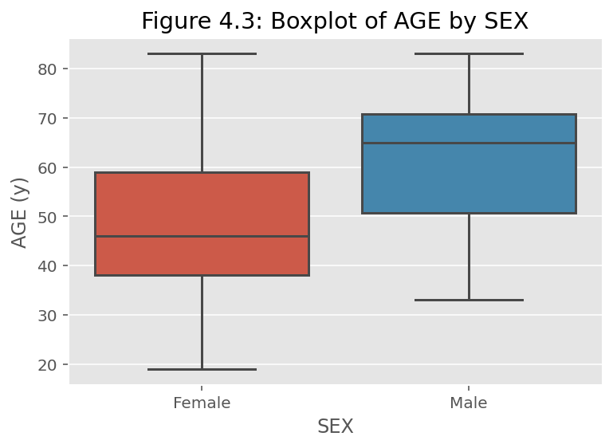

```python
# Generate a boxplot of AGE by SEX
sns.boxplot(data["SEX"], data["AGE"]).set(title="Figure 4.3: Boxplot of AGE by SEX", ylabel="AGE (y)")
plt.show;
```

Next we take a look at `RETPLASMA` by `VITUSE`.

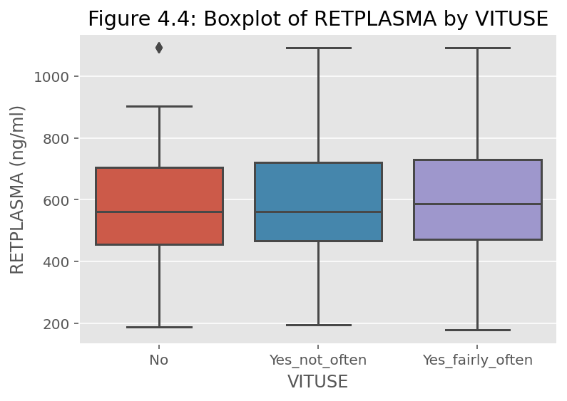

```python
# Generate boxplots of RETPLASMA by VITUSE
sns.boxplot(x=data["VITUSE"], y=data["RETPLASMA"], order=["No","Yes_not_often",
                "Yes_fairly_often"]).set(xlabel="VITUSE", ylabel="RETPLASMA (ng/ml)",
                        title = "Figure 4.4: Boxplot of RETPLASMA by VITUSE")
plt.show;
```

This is interesting—Figure 4.4 appears to hint at a weak correlation between vitamin supplement use and plasma retinol levels.

```python
#Generate new dataframes, one for each unique response to VITUSE
frequent_vit = data[data["VITUSE"]=="Yes_fairly_often"]["RETPLASMA"].describe()
infrequent_vit = data[data["VITUSE"]=="Yes_not_often"]["RETPLASMA"].describe()
no_vit = data[data["VITUSE"]=="No"]["RETPLASMA"].describe()

#Generate basic descriptive stats
print("{:15}Frequent: {:>6}        Infrequent: {:>6}        None: {:>6}".format("COUNT",frequent_vit[0],infrequent_vit[0],no_vit[0]))
print("{:15}Frequent: {:>6}        Infrequent: {:>6}        None: {:>6}".format("MEAN",frequent_vit[1].round(2),infrequent_vit[1].round(2),no_vit[1].round(2)))
print("{:15}Frequent: {:>6}        Infrequent: {:>6}        None: {:>6}".format("STD DEV",frequent_vit[2].round(2),infrequent_vit[2].round(2),no_vit[2].round(2)))
print("{:15}Frequent: {:>6}        Infrequent: {:>6}        None: {:>6}".format("MINIMUM",frequent_vit[3],infrequent_vit[3],no_vit[3]))
print("{:15}Frequent: {:>6}        Infrequent: {:>6}        None: {:>6}".format("Q1",frequent_vit[4],infrequent_vit[4],no_vit[4]))
print("{:15}Frequent: {:>6}        Infrequent: {:>6}        None: {:>6}".format("MEDIAN",frequent_vit[5],infrequent_vit[5],no_vit[5]))
print("{:15}Frequent: {:>6}        Infrequent: {:>6}        None: {:>6}".format("Q3",frequent_vit[6],infrequent_vit[6],no_vit[6]))
print("{:15}Frequent: {:>6}        Infrequent: {:>6}        None: {:>6}".format("MAXIMUM",frequent_vit[7],infrequent_vit[7],no_vit[7]))
```

```
COUNT          Frequent:  122.0        Infrequent:   82.0        None:  111.0
MEAN           Frequent: 607.04        Infrequent: 592.98        None: 588.22
STD DEV        Frequent: 205.71        Infrequent: 176.16        None: 175.77
MINIMUM        Frequent:  179.0        Infrequent:  194.0        None:  187.0
Q1             Frequent: 471.25        Infrequent:  467.0        None:  456.0
MEDIAN         Frequent:  587.5        Infrequent:  562.0        None:  561.0
Q3             Frequent: 729.25        Infrequent:  720.5        None:  705.0
MAXIMUM        Frequent: 1091.0        Infrequent: 1091.0        None: 1091.0
```

Measures of centre can be seen increasing for each higher category of vitamin use. $Q_1$ and $Q_3$ exhibit similar behaviour, although maximums are all clamped at 1091.0 and minimums do not display a similar uptrend. Measures of centre and the positions of quartiles are given more creedence though, so we do suspect that we will see the `VITUSE` feature having some effect on plasma retinol levels in our complete model.  
Next let us look at the relationship between `SEX` and `RETPLASMA`.

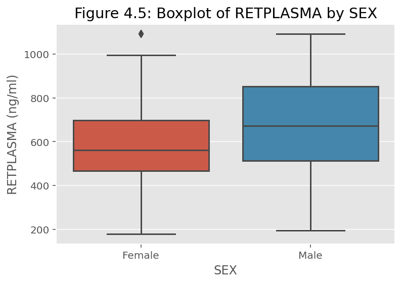

```python
# Generate a boxplot for RETPLASMA by SEX
sns.boxplot(x=data["SEX"], y=data["RETPLASMA"]).set(xlabel="SEX", ylabel="RETPLASMA (ng/ml)",
                                    title = "Figure 4.5: Boxplot of RETPLASMA by SEX")
plt.show;
```

Figure 4.5 visualises a very clear correlation between `SEX` and `RETPLASMA`. Let us clarify by generating some descriptive statistics for both male and female plasma retinol concentrations.

```python
#Generate two new dataframes, one containing female observations, one containing male
females = data[data["SEX"]=="Female"]["RETPLASMA"].describe()
males = data[data["SEX"]=="Male"]["RETPLASMA"].describe()

#Generate basic descriptive stats
print("{:15}Male: {:>6}        Female: {:>6}".format("COUNT",males[0],females[0]))
print("{:15}Male: {:>6}        Female: {:>6}".format("MEAN",males[1].round(2),females[1].round(2)))
print("{:15}Male: {:>6}        Female: {:>6}".format("STD DEV",males[2].round(2),females[2].round(2)))
print("{:15}Male: {:>6}        Female: {:>6}".format("MINIMUM",males[3],females[3]))
print("{:15}Male: {:>6}        Female: {:>6}".format("Q1",males[4],females[4]))
print("{:15}Male: {:>6}        Female: {:>6}".format("MEDIAN",males[5],females[5]))
print("{:15}Male: {:>6}        Female: {:>6}".format("Q3",males[6],females[6]))
print("{:15}Male: {:>6}        Female: {:>6}".format("MAXIMUM",males[7],females[7]))
```

```
COUNT          Male:   42.0        Female:  273.0
MEAN           Male: 675.33        Female: 584.66
STD DEV        Male: 249.66        Female: 173.63
MINIMUM        Male:  194.0        Female:  179.0
Q1             Male:  513.0        Female:  466.0
MEDIAN         Male:  672.0        Female:  561.0
Q3             Male: 852.75        Female:  697.0
MAXIMUM        Male: 1091.0        Female: 1091.0
```

It can be seen that with the exception of maximum—which is a clamped value of 1091.0 in both sexes—every statistic describing plasma retinol concentrations is higher for male subjects of the study than female. As such, we anticipate that `SEX` will have a non-negligible role in modelling plasma retinol levels.

The final categorical feature remaining to examine is `SMOKSTAT`. The old adage is true:

> If it ain't broke; don't fix it.

So we will use the faithful boxplot again to examine subjects' plasma retinol levels by their smoking status.

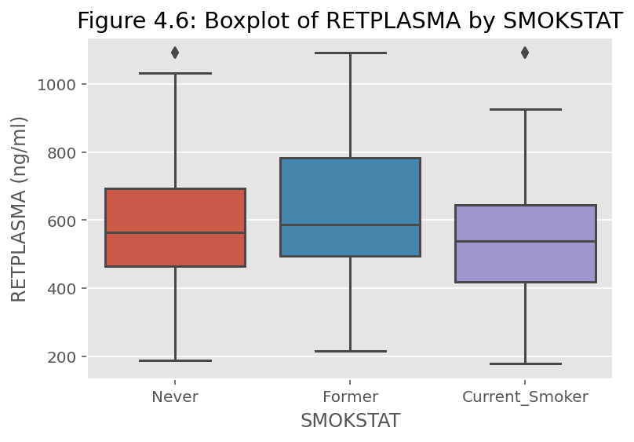

```python
# Generate boxplots of RETPLASMA by SMOKSTAT
sns.boxplot(x=data["SMOKSTAT"], y=data["RETPLASMA"], order=["Never","Former",
                "Current_Smoker"]).set(xlabel="SMOKSTAT", ylabel="RETPLASMA (ng/ml)",
                        title = "Figure 4.6: Boxplot of RETPLASMA by SMOKSTAT")
plt.show;
```

The boxplots in Figure 4.6 show no pattern in plasma retinol concentrations as affected by a subject's smoking status. There doesn't seem to be any reason to presume that the higher measures of centre and spread in the "Former" category of `SMOKSTAT` are due to anything other than random variation.

### Exploration of Numerical Features

Having explored categorical features, let us visualise the numerical features of the dataset and see what we can learn. A `Seaborn` `PairGrid` will be used to generate a matrix visualising the correlation between each pair of numerical features.

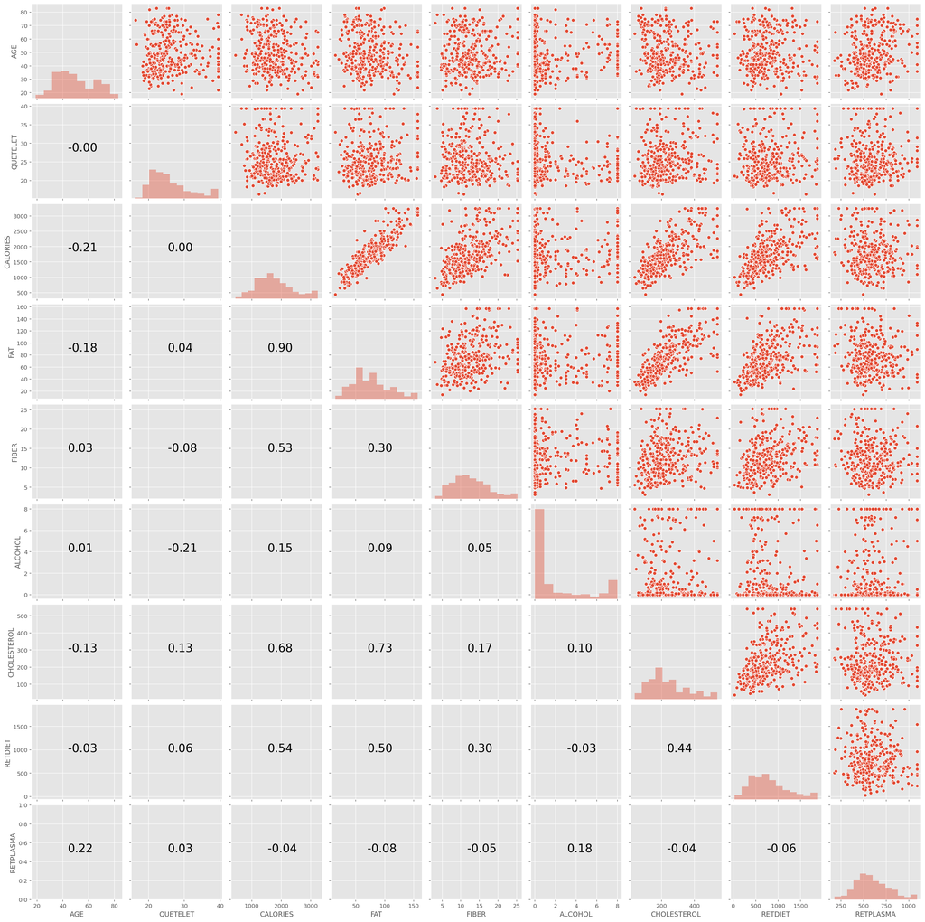

```python
## Code in this block is sourced from Ture (2020)

def corrfunc(x, y, **kws):
    r, _ = stats.pearsonr(x, y)
    ax = plt.gca()
    ax.annotate("{:.2f}".format(r),
                xy=(.4, .5), xycoords = ax.transAxes, fontsize = 20)

# Generate a PairGrid of all numerical features, showing: scatter plots, histograms, and r values
g = sns.PairGrid(data, vars = ["AGE", "QUETELET", "CALORIES", "FAT", "FIBER", "ALCOHOL",
                                                   "CHOLESTEROL", "RETDIET", "RETPLASMA"])
g.map_upper(sns.scatterplot)
g.map_lower(corrfunc)
g.map_diag(sns.distplot, kde = False)
plt.show();
```

Figure 4.7: Pair grid showing correlation and scatterplots between each pair of numerical features, as well as histograms of each single numerical feature.

Unforunately Figure 4.7 doesn't show any obvious relationships of particular relevance. There are some clear correlations between dietary features, which are expected given their related nature. As mentioned during data preparation, we may see some multicollinearity in these dietary features. Under the assumption that most people eat an averagely balanced diet, their dietary intake of macro- and micronutrients might thus be reasonably predicted simply from their caloric intake, `CALORIES`. As such we suspect that if we see multicollinearity between these features, the following relationships will be at work:

- `FAT` $\propto$ `CALORIES`
- `CHOLESTEROL` $\propto$ `CALORIES`
- `FIBRE` $\propto$ `CALORIES`
- `RETDIET` $\propto$ `CALORIES`

Most other plots appear to be quite random. Although those involving the `ALCOHOL` feature have a peculiar form, which exhibits little variation from plot to plot. As a result, we suspect that a subject's weekly alcohol intake is fairly independent of the other features in the dataset. Let's take a closer look.

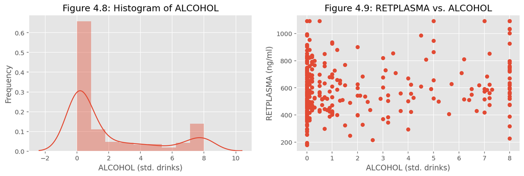

```python
# Set up the plot grid
plt.subplots(1,2, figsize=(14,4))

# Generate a histogram of ALCOHOL
plt.subplot(1,2,1)
sns.distplot(data["ALCOHOL"], kde=True).set(title="Figure 4.8: Histogram of ALCOHOL",
                                    xlabel="ALCOHOL (std. drinks)", ylabel="Frequency")

# Generate a scatter plot of RETPLASMA vs. ALCOHOL
plt.subplot(1,2,2)
plt.scatter(data["ALCOHOL"], data["RETPLASMA"])
plt.xlabel("ALCOHOL (std. drinks)")
plt.ylabel("RETPLASMA (ng/ml)")
plt.title("Figure 4.9: RETPLASMA vs. ALCOHOL")

plt.show;
```

It can be seen that a lot of the observations on weekly alcohol intake are clustered around 0—unsurprising as there is certainly a portion of most human populations that drink either little or not at all. Figure 4.9 appears to show a very slight positive correlation, so a quick-and-dirty single linear regression might help us determine if anything significant is going on here.

```python
# Generate and summarise a simple linear regression for RETPLASMA and ALCOHOL
formula_string = "RETPLASMA ~ ALCOHOL"

model = sm.formula.ols(formula = formula_string, data = data)
model_fitted = model.fit()

print(model_fitted.summary())
```

```
                            OLS Regression Results
==============================================================================
Dep. Variable:              RETPLASMA   R-squared:                       0.033
Model:                            OLS   Adj. R-squared:                  0.029
Method:                 Least Squares   F-statistic:                     10.53
Date:                Sat, 31 Oct 2020   Prob (F-statistic):            0.00130
Time:                        23:02:10   Log-Likelihood:                -2090.1
No. Observations:                 315   AIC:                             4184.
Df Residuals:                     313   BIC:                             4192.
Df Model:                           1
Covariance Type:            nonrobust
==============================================================================
                 coef    std err          t      P>|t|      [0.025      0.975]
------------------------------------------------------------------------------
Intercept    572.9917     12.731     45.008      0.000     547.943     598.041
ALCOHOL       11.9226      3.675      3.244      0.001       4.692      19.153
==============================================================================
Omnibus:                       10.845   Durbin-Watson:                   1.541
Prob(Omnibus):                  0.004   Jarque-Bera (JB):               11.407
Skew:                           0.465   Prob(JB):                      0.00333
Kurtosis:                       2.941   Cond. No.                         4.36
==============================================================================

Warnings:
[1] Standard Errors assume that the covariance matrix of the errors is correctly specified.
```

Our expedient regression has a disappointingly low $R^2$ value, although this should hardly come as a surprise given the nature of our scatter plot. Interestingly there is a positive coefficient of 11.9226 and the p-value of 0.001 indicates that this is statistically signifcant at the default 0.005 significance level. So while the `ALCOHOL` feature does not appear to be an accurate predictor of variation in `RETPLASMA`, we might not want to rule it out as playing a decent part here.

# Modelling and Evaluation

### Encoding Categorical Features

In order to encode categorical features for modelling, they must be `object` types. We first check the data types of each feature.

```python
data.dtypes
```

```
AGE              int64
SEX             object
SMOKSTAT        object
QUETELET       float64
VITUSE          object
CALORIES       float64
FAT            float64
FIBER          float64
ALCOHOL        float64
CHOLESTEROL    float64
RETDIET          int64
RETPLASMA        int64
dtype: object
```

We have previously identified the dataset's categorical features as `SEX`, `SMOKSTAT`, and `VITUSE`, and we can see above that these are already of the correct data type. The former is nominal and requires one-hot-encoding, the latter two are ordinal and will require integer-encoding.  
Integer encoding was selected for the `SMOKSTAT` and `VITUSE` features because we deem it more useful to assign value to the "healthier" responses and accept a level of uncertainty, than to simply treat the different responses as unrelated or of equivalent value.

```python
# Integer encode the categorical features SMOKSTAT and VITUSE
smokstat_mapping = {"Current_Smoker": 0, "Former": 1, "Never": 2}
vituse_mapping = {"No": 0, "Yes_not_often": 1, "Yes_fairly_often": 2}
data_encoded = data.copy()
data_encoded["SMOKSTAT"]=data_encoded["SMOKSTAT"].replace(smokstat_mapping)
data_encoded["VITUSE"]=data_encoded["VITUSE"].replace(vituse_mapping)

data_encoded.head(5)
```

|  | AGE | SEX | SMOKSTAT | QUETELET | VITUSE | CALORIES | FAT | FIBER | ALCOHOL | CHOLESTEROL | RETDIET | RETPLASMA |
| --- | --- | --- | --- | --- | --- | --- | --- | --- | --- | --- | --- | --- |
| 0 | 64 | Female | 1 | 21.48380 | 2 | 1298.8 | 57.0 | 6.300 | 0.0 | 170.3 | 890 | 915 |
| 1 | 76 | Female | 2 | 23.87631 | 2 | 1032.5 | 50.1 | 15.800 | 0.0 | 75.8 | 451 | 727 |
| 2 | 38 | Female | 1 | 20.01080 | 1 | 2372.3 | 83.6 | 19.100 | 8.0 | 257.9 | 660 | 721 |
| 3 | 40 | Female | 1 | 25.14062 | 0 | 2449.5 | 97.5 | 25.275 | 0.5 | 332.6 | 864 | 615 |
| 4 | 72 | Female | 2 | 20.98504 | 2 | 1952.1 | 82.6 | 16.200 | 0.0 | 170.8 | 1209 | 799 |

The nominal feature `SEX` is next one-hot-encoded.

```python
#One-hot-encode the categorical feature SEX
data_encoded = pd.get_dummies(data_encoded, columns=["SEX"], drop_first=True)

data_encoded.head(5)
```

|  | AGE | SMOKSTAT | QUETELET | VITUSE | CALORIES | FAT | FIBER | ALCOHOL | CHOLESTEROL | RETDIET | RETPLASMA | SEX_Male |
| --- | --- | --- | --- | --- | --- | --- | --- | --- | --- | --- | --- | --- |
| 0 | 64 | 1 | 21.48380 | 2 | 1298.8 | 57.0 | 6.300 | 0.0 | 170.3 | 890 | 915 | 0 |
| 1 | 76 | 2 | 23.87631 | 2 | 1032.5 | 50.1 | 15.800 | 0.0 | 75.8 | 451 | 727 | 0 |
| 2 | 38 | 1 | 20.01080 | 1 | 2372.3 | 83.6 | 19.100 | 8.0 | 257.9 | 660 | 721 | 0 |
| 3 | 40 | 1 | 25.14062 | 0 | 2449.5 | 97.5 | 25.275 | 0.5 | 332.6 | 864 | 615 | 0 |
| 4 | 72 | 2 | 20.98504 | 2 | 1952.1 | 82.6 | 16.200 | 0.0 | 170.8 | 1209 | 799 | 0 |

Thus for the `SEX` feature, the reference level in the model will be "Female", i.e. `SEX_Male` equal to 0.  
Now that we have established the `data_encoded` dataframe which has been properly prepared and encoded, Mutliple Linear Regression can be applied to the data.

### Full Model

The first step is to create a formula string. Then the model can be constructed and we can run Multiple Linear Regression.

```python
# Create a string representing the formula for the full model
formula_string = " + ".join(data_encoded.drop(columns="RETPLASMA").columns)
formula_string = "RETPLASMA ~ " + formula_string

print("The full model formula string is:\n", formula_string)
```

```
The full model formula string is:
 RETPLASMA ~ AGE + SMOKSTAT + QUETELET + VITUSE + CALORIES + FAT + FIBER + ALCOHOL + CHOLESTEROL + RETDIET + SEX_Male
```

```python
# Construct the model and perform Multiple Linear Regression
model_full = sm.formula.ols(formula=formula_string, data=data_encoded)
model_full_fitted = model_full.fit()

# Print the regression summary
print(model_full_fitted.summary())
```

```
                            OLS Regression Results
==============================================================================
Dep. Variable:              RETPLASMA   R-squared:                       0.122
Model:                            OLS   Adj. R-squared:                  0.091
Method:                 Least Squares   F-statistic:                     3.841
Date:                Sat, 31 Oct 2020   Prob (F-statistic):           3.40e-05
Time:                        23:02:10   Log-Likelihood:                -2074.8
No. Observations:                 315   AIC:                             4174.
Df Residuals:                     303   BIC:                             4219.
Df Model:                          11
Covariance Type:            nonrobust
===============================================================================
                  coef    std err          t      P>|t|      [0.025      0.975]
-------------------------------------------------------------------------------
Intercept     393.8174     77.247      5.098      0.000     241.809     545.826
AGE             2.7932      0.783      3.566      0.000       1.252       4.335
SMOKSTAT       -9.6997     15.117     -0.642      0.522     -39.447      20.047
QUETELET        2.6761      1.948      1.374      0.170      -1.157       6.509
VITUSE         18.6336     12.340      1.510      0.132      -5.649      42.916
CALORIES        0.1204      0.053      2.268      0.024       0.016       0.225
FAT            -2.0314      0.886     -2.292      0.023      -3.775      -0.287
FIBER          -5.7761      2.929     -1.972      0.050     -11.540      -0.012
ALCOHOL        10.8959      3.908      2.788      0.006       3.206      18.586
CHOLESTEROL    -0.0541      0.131     -0.414      0.679      -0.311       0.203
RETDIET        -0.0180      0.029     -0.613      0.540      -0.076       0.040
SEX_Male       52.4240     33.829      1.550      0.122     -14.145     118.993
==============================================================================
Omnibus:                        6.858   Durbin-Watson:                   1.513
Prob(Omnibus):                  0.032   Jarque-Bera (JB):                6.931
Skew:                           0.363   Prob(JB):                       0.0313
Kurtosis:                       2.985   Cond. No.                     1.60e+04
==============================================================================

Warnings:
[1] Standard Errors assume that the covariance matrix of the errors is correctly specified.
[2] The condition number is large, 1.6e+04. This might indicate that there are
strong multicollinearity or other numerical problems.
```

The summary shows that the full Multiple Linear Regression model has $R^2$ equal to 0.122 and $R^2_{adj}$ equal to 0.091. This implies that only 9.1% of variation in plasma retinol levels is explained by the model.

The following features have p-values greater than the 0.05 level of significance:

| **Feature** | **p-value** |
| --- | --- |
| `SMOKSTAT` | 0.522 |
| `QUETELET` | 0.170 |
| `VITUSE` | 0.132 |
| `CHOLESTEROL` | 0.679 |
| `RETDIET` | 0.540 |
| `SEX_Male` | 0.122 |

We therefore suspect that they are not statistically significant in predicting `RETPLASMA` and will likely be eliminated by backwards feature selection. Note that the p-value of `FIBER` is marginal, we will see later whether or not this feature is significant.

Let's take a sample of residuals from the regression. We build a new dataframe with the features: actual and predicted plasma retinol levels as well as the difference—residual—between these values. We sample ten observations at random.

```python
# Create a new dataframe for the MLR residuals
residuals_full = pd.DataFrame({"ACTUAL": data_encoded["RETPLASMA"],
                            "PREDICTED": model_full_fitted.fittedvalues,
                            "RESIDUAL": model_full_fitted.resid})

# Get a random sample of observations from the residuals dataframe
residuals_full.sample(10, random_state=999)
```

|  | ACTUAL | PREDICTED | RESIDUAL |
| --- | --- | --- | --- |
| 151 | 416 | 540.829313 | -124.829313 |
| 168 | 428 | 517.780882 | -89.780882 |
| 197 | 399 | 592.298417 | -193.298417 |
| 27 | 691 | 651.700538 | 39.299462 |
| 145 | 402 | 541.380286 | -139.380286 |
| 3 | 615 | 485.758336 | 129.241664 |
| 45 | 546 | 685.526704 | -139.526704 |
| 246 | 647 | 515.389019 | 131.610981 |
| 30 | 818 | 513.474112 | 304.525888 |
| 124 | 669 | 577.999499 | 91.000501 |

Let's put the residuals in perspective by recalling some key statistics of the target feature `RETPLASMA`.

```python
data["RETPLASMA"].describe()
```

```
count     315.000000
mean      596.746032
std       187.631887
min       179.000000
25%       466.000000
50%       566.000000
75%       716.000000
max      1091.000000
Name: RETPLASMA, dtype: float64
```

The `RETPLASMA` feature has standard deviation of about 188, with it's lower and upper quartiles at 466 and 716 respectively. Just as a ballpark check, we can see that of the ten sampled observations from the residual dataframe, most predicted values are less than one standard deviation from their actual value, and all are within two standard deviations. They also all fall between the lower and upper quartile. So the model is not unreasonable, but there is more work to be done.

We next generate a scatter plot of the predicted `RETPLASMA` values vs. the actual values. The line $y=x$ is drawn over the plot for reference because an ideal regression would produce a scatter plot where points would be distributed on or very close to this line.

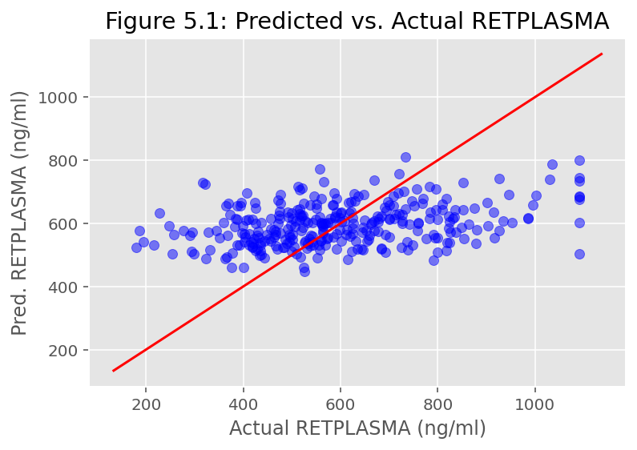

```python
# Method to plot a simple linear equation on a plot
# Sourced from Aksakalli et al. (2020)
def plot_line(axis, slope, intercept, **kargs):
    xmin, xmax = axis.get_xlim()
    plt.plot([xmin, xmax], [xmin*slope+intercept, xmax*slope+intercept], **kargs)

# Generate a scatter plot of predicted vs. actual RETPLASMA
plt.scatter(residuals_full["ACTUAL"], residuals_full["PREDICTED"],c = "blue", alpha=0.5);
plot_line(axis=plt.gca(), slope=1, intercept=0, c="red");
plt.xlabel("Actual RETPLASMA (ng/ml)");
plt.ylabel("Pred. RETPLASMA (ng/ml)");
plt.title("Figure 5.1: Predicted vs. Actual RETPLASMA");
plt.show();
```

While the model is exhibiting a weak positive linear relationship, we are still a long way from home. We can see that low and high values are being over and underestimated respectively.

We want to carry out some quick condition checking for the full model. This is a good idea because it means we can ensure that nothing is amiss with the model before we commit to it and and attempt to simplify it.  
We use the `seaborn` and `matplotlib` modules to generate a scatter plot and a histogram of residuals for analysis.

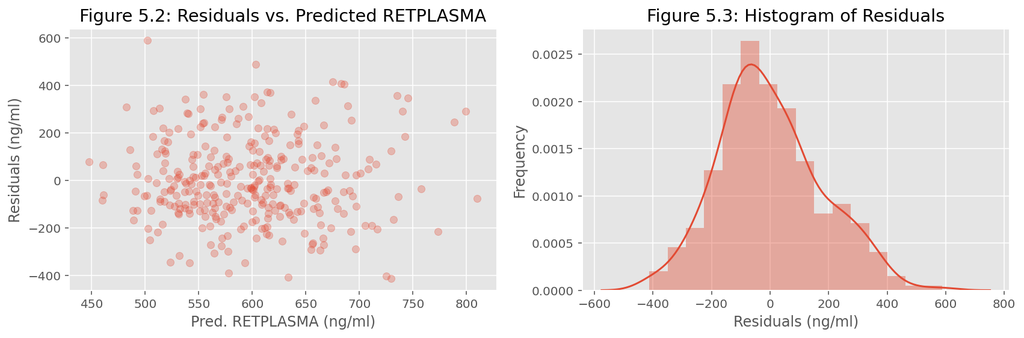

```python
# Set up the plot grid
plt.subplots(1,2, figsize=(14,4))

#Generate a scatter plot of Residuals vs. Predicted RETPLASMA
plt.subplot(1,2,1)
plt.scatter(residuals_full["PREDICTED"], residuals_full["RESIDUAL"], alpha=0.3);
plt.xlabel("Pred. RETPLASMA (ng/ml)");
plt.ylabel("Residuals (ng/ml)")
plt.title("Figure 5.2: Residuals vs. Predicted RETPLASMA")

#Generate a scatter plot of Residuals vs. Actual RETPLASMA
plt.subplot(1,2,2)
sns.distplot(residuals_full["RESIDUAL"], kde=True).set(title="Figure 5.3: Histogram of Residuals",
                                                      xlabel="Residuals (ng/ml)", ylabel="Frequency")

plt.show();
```

Linearity and constant variability are apparent from the scatter plot in Figure 5.2, which shows no suspect trend or uneven distribution of residuals. The histogram in Figure 5.3 visualises nearly normal residuals, so condition checks are passed under the assumption that observations and thus residuals are independent to boot.

### Backwards Feature Selection for the Reduced Model

First, why choose this approach? Backwards feature selection is used because for our purposes it presents as significantly less laborious than forwards feature selection. And why the p-value approach specifically? We determine that as this project is not necesssarily Machine-Learning-focused, we are most concerned with determining the statistically significant features affecting plasma retinol levels, moreso than we are with pure prediction accuracy.

Aksakalli et al. (2020) provide a fantastic block of code for automatic backwards feature selection, and such is its elegance that we would be remiss not to make use of it. The code loops over the full fitted model, sorting features in descending order of p-value, removing the top (highest p-value) feature if its p-value > level of significance (0.05), and refitting the model. It continues until no p-values exceeding the significance level remain, and then returns the reduced fitted model for use as `model_reduced_fitted`.

```python
## Code in this block is sourced from Aksakalli et al. (2020). It has been adapted in style
## only to match other code in this report, otherwise it remains unchanged.
## WARNING 1: The code below assumes that the Intercept term is present in the model.
## WARNING 2: It will work only with main effects and two-way interactions, if any.

# Create the patsy model description from formula
patsy_description = patsy.ModelDesc.from_formula(formula_string)

# Initialize feature-selected fit to full model
linreg_fit = model_full_fitted

# Carry out backwards feature elimination based on p-values
p_val_cutoff = 0.05

print("\nPerforming backwards feature selection using p-values:")

while True:
    #print(linreg_fit.summary())
    pval_series = linreg_fit.pvalues.drop(labels="Intercept")
    pval_series = pval_series.sort_values(ascending=False)
    term = pval_series.index[0]
    pval = pval_series[0]
    if (pval < p_val_cutoff):
        break
    term_components = term.split(':')
    print(f'\nRemoving term "{term}" with p-value {pval:.4}')
    if (len(term_components) == 1):    # This is a main effect term
        patsy_description.rhs_termlist.remove(patsy.Term([patsy.EvalFactor(term_components[0])]))
    else:                              # This is an interaction term
        patsy_description.rhs_termlist.remove(patsy.Term([patsy.EvalFactor(term_components[0]),
                                                        patsy.EvalFactor(term_components[1])]))

    linreg_fit = smf.ols(formula=patsy_description, data=data_encoded).fit()

# Perform MLR on the clean fit after backwards elimination of features
model_reduced_fitted = smf.ols(formula = patsy_description, data = data_encoded).fit()

print("\n")
print(model_reduced_fitted.summary())
print(f"\nRegression number of terms: {len(model_reduced_fitted.model.exog_names)}")
print(f"Regression F-distribution p-value: {model_reduced_fitted.f_pvalue:.4f}")
print(f"Regression R-squared: {model_reduced_fitted.rsquared:.4f}")
print(f"Regression Adjusted R-squared: {model_reduced_fitted.rsquared_adj:.4f}")
```

```
Performing backwards feature selection using p-values:

Removing term "CHOLESTEROL" with p-value 0.6788

Removing term "SMOKSTAT" with p-value 0.5257

Removing term "RETDIET" with p-value 0.4916

Removing term "QUETELET" with p-value 0.2173

Removing term "VITUSE" with p-value 0.1845

Removing term "SEX_Male" with p-value 0.1299


                            OLS Regression Results
==============================================================================
Dep. Variable:              RETPLASMA   R-squared:                       0.103
Model:                            OLS   Adj. R-squared:                  0.089
Method:                 Least Squares   F-statistic:                     7.110
Date:                Sat, 31 Oct 2020   Prob (F-statistic):           2.59e-06
Time:                        23:02:12   Log-Likelihood:                -2078.2
No. Observations:                 315   AIC:                             4168.
Df Residuals:                     309   BIC:                             4191.
Df Model:                           5
Covariance Type:            nonrobust
==============================================================================
                 coef    std err          t      P>|t|      [0.025      0.975]
------------------------------------------------------------------------------
Intercept    441.9938     52.870      8.360      0.000     337.962     546.025
AGE            3.1486      0.728      4.325      0.000       1.716       4.581
CALORIES       0.1239      0.051      2.422      0.016       0.023       0.225
FAT           -2.1468      0.850     -2.527      0.012      -3.819      -0.475
FIBER         -6.3544      2.865     -2.218      0.027     -11.991      -0.717
ALCOHOL       10.4562      3.648      2.867      0.004       3.279      17.633
==============================================================================
Omnibus:                       12.167   Durbin-Watson:                   1.526
Prob(Omnibus):                  0.002   Jarque-Bera (JB):               12.787
Skew:                           0.493   Prob(JB):                      0.00167
Kurtosis:                       3.033   Cond. No.                     9.85e+03
==============================================================================

Warnings:
[1] Standard Errors assume that the covariance matrix of the errors is correctly specified.
[2] The condition number is large, 9.85e+03. This might indicate that there are
strong multicollinearity or other numerical problems.

Regression number of terms: 6
Regression F-distribution p-value: 0.0000
Regression R-squared: 0.1032
Regression Adjusted R-squared: 0.0887
```

Again, we build a new dataframe containing actual and predicted plasma retinol levels as well as the residuals, and sample ten observations at random.

```python
# Create a new dataframe for the backwards feature selected MLR residuals
residuals_reduced = pd.DataFrame({"ACTUAL": data_encoded["RETPLASMA"],
"PREDICTED": model_reduced_fitted.fittedvalues,
"RESIDUAL": model_reduced_fitted.resid})

# Get a random sample of observations from the residuals dataframe
residuals_reduced.sample(10, random_state=999)
```

|  | ACTUAL | PREDICTED | RESIDUAL |
| --- | --- | --- | --- |
| 151 | 416 | 531.912722 | -115.912722 |
| 168 | 428 | 521.848765 | -93.848765 |
| 197 | 399 | 604.556553 | -205.556553 |
| 27 | 691 | 644.141995 | 46.858005 |
| 145 | 402 | 567.448806 | -165.448806 |
| 3 | 615 | 506.659895 | 108.340105 |
| 45 | 546 | 686.314834 | -140.314834 |
| 246 | 647 | 522.642200 | 124.357800 |
| 30 | 818 | 529.780868 | 288.219132 |
| 124 | 669 | 599.069779 | 69.930221 |

### Condition Checking

The validity of a multiple regression model hinges on key conditions that must be met before we can begin analysing a model:

**Linearity:** The data should show a linear correlation between explanatory and response variables. This is assessed using a plot of residuals. If the correlation were non-linear we would expect to see non-linearity in the residual plot as the model tried to describe a non-linear relationship with a straight line.

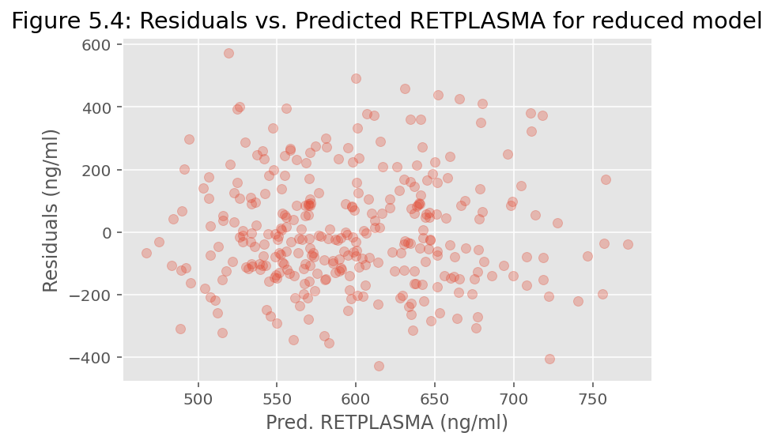

```python
# Generate a scatter plot of Predicted vs. Actual RETPLASMA for the reduced model
plt.scatter(residuals_reduced["PREDICTED"], residuals_reduced["RESIDUAL"], alpha=0.3);
plt.xlabel("Pred. RETPLASMA (ng/ml)");
plt.ylabel("Residuals (ng/ml)")
plt.title("Figure 5.4: Residuals vs. Predicted RETPLASMA for reduced model")
plt.show();
```

The residuals don't exhibit any clear trend and are distributed fairly evenly around the zero-line, which implies linearity.  
**Independence:** We assume that residuals are independent because observations in the original study and thus our dataset are presumed to be independent.

**Nearly normal residuals:** Distirbution of residuals must be nearly normal. We check for normality of residuals by generating a histogram using the `Seaborn` module.

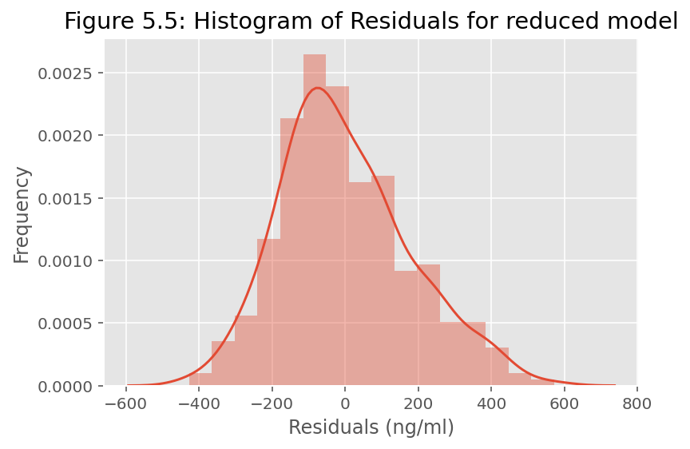

```python
# Generate a histogram of residuals of the reduced model
sns.distplot(residuals_reduced["RESIDUAL"], kde=True).set(title=
    "Figure 5.5: Histogram of Residuals for reduced model", xlabel="Residuals (ng/ml)", ylabel="Frequency")
plt.show;
```

Some right-skewness can be observed, but residuals appear to be sufficiently normal.  
**Constant variablity:** Variability of points around the least-squares line must remain roughly constant. This implies that the variability of residuals should be roughly constant too, so we can confirm using another residual plot.

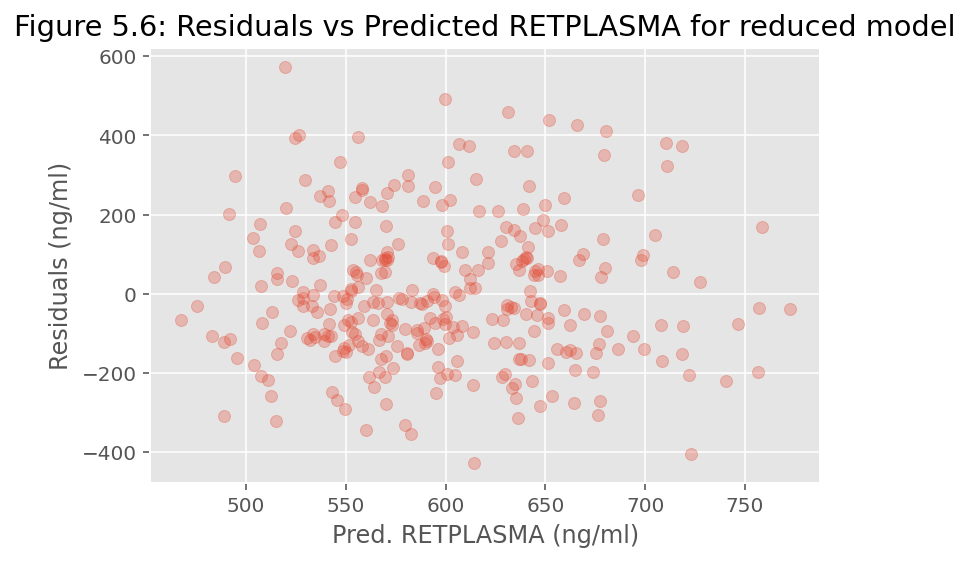

```python
# Generate a scatter plot of Residuals vs. Predicted RETPLASMA for reduced model
plt.scatter(residuals_reduced["PREDICTED"], residuals_reduced["RESIDUAL"], alpha=0.3);
plt.xlabel("Pred. RETPLASMA (ng/ml)");
plt.ylabel("Residuals (ng/ml)")
plt.title("Figure 5.6: Residuals vs Predicted RETPLASMA for reduced model")

plt.show();
```

The plot of Residuals vs. Predicted `RETPLASMA` is indicative of constant variability as the residuals appear in roughly even proportions and distances on either side of the zero-line.  
We can now be satisfied that our reduced model has passed the condtion checks.

### Further Descriptors of Reduced Model

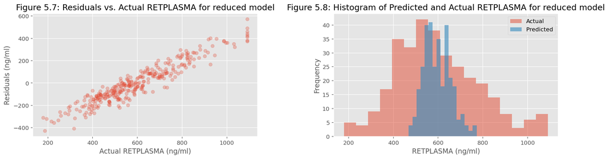

```python
# Set up the plot grid
plt.subplots(1,2, figsize=(15,4))

#Generate a scatter plot of Residuals vs. Predicted RETPLASMA for reduced model
plt.subplot(1,2,1)
plt.scatter(residuals_reduced["ACTUAL"], residuals_reduced["RESIDUAL"], alpha=0.3);
plt.xlabel("Actual RETPLASMA (ng/ml)");
plt.ylabel("Residuals (ng/ml)")
plt.title("Figure 5.7: Residuals vs. Actual RETPLASMA for reduced model")

#Generate a scatter plot of Residuals vs. Actual RETPLASMA for reduced model
plt.subplot(1,2,2)
plt.hist(residuals_reduced["ACTUAL"], label="Actual", bins=17, alpha=0.5);
plt.hist(residuals_reduced["PREDICTED"], label="Predicted", bins=17, alpha=0.6);
plt.xlabel("RETPLASMA (ng/ml)");
plt.ylabel("Frequency");
plt.title("Figure 5.8: Histogram of Predicted and Actual RETPLASMA for reduced model");
plt.legend()

plt.tight_layout()
plt.show();
```

Recalling that $residual = actual\space value - predicted\space value$, it can be seen from Figure 5.7 that the model still appears to overestimate low `RETPLASMA` measurements and underestimate high measurements. The histogram in Figure 5.8 reflects the same observation, with the model being somewhat accurate in terms of centre but being much narrower in its predictions than the actual observed values.

We now use `statsmodels` to calculate confidence intervals for the coefficients before jumping in to analyse the reduced model.

```python
# Calculate the 95% confidence intervals for feature coefficients
model_reduced_fitted.conf_int(0.05)
```

|  | 0 | 1 |
| --- | --- | --- |
| Intercept | 337.962497 | 546.025006 |
| AGE | 1.716027 | 4.581170 |
| CALORIES | 0.023226 | 0.224513 |
| FAT | -3.818560 | -0.475127 |
| FIBER | -11.991400 | -0.717372 |
| ALCOHOL | 3.278968 | 17.633450 |

# Analysis and Conclusions

[figure not shown]

> "And if you labelled your axes, I could tell you exactly how MUCH better." Source: Munroe (2010)

We summarise the results of the reduced model as such:

- The $R^2_{adj}$ value of 0.089 suggests that 8.9% of variability in `RETPLASMA` is explained by variability in the remaining explanatory features.
- The `Intercept` occurs at 441.99 with the 95% confidence interval placing it between 337.96 and 546.03. It has little meaning independent of the explanatory features, zero-values for which would imply illogicalities such as an age of 0 and no calories consumed per day.
- `AGE` has a coefficient of 3.15 (95% confidence interval between 1.72 and 4.58) implying a 1 year increase to age predicts an increase of 3.15$ng$ of retinol per $ml$ of plasma, all else being equal.
- `CALORIES` has a coefficient of 0.12 (95% confidence interval between 0.023 and 0.225) implying a 100 calorie increase per day predicts an increase of 12$ng$ of retinol per $ml$ of plasma, all else being equal.
- `FAT` has a coefficient of -2.15 (95% confidence interval between -3.82 and -0.48) implying a 1 gram increase in daily fat intake predicts a decrease of 2.15$ng$ of retinol per $ml$ of plasma, all else being equal.
- `FIBRE` has a coefficient of -6.35 (95% confidence interval between -11.99 and -0.72) implying a 1 gram increase in daily fibre intake predicts a decrease of 6.35$ng$ of retinol per $ml$ of plasma, all else being equal.
- `ALCOHOL` has a coefficient of 10.46 (95% confidence interval between 3.28 and 17.63) implying an extra standard drink per week predicts an increase of 10.46$ng$ of retinol per $ml$ of plasma, all else being equal.

We had suspected some collinearity between the dietary features `CALORIES`, `FAT` and `FIBER` however it can be seen that the coefficient of the caloric intake feature (0.12) expresses a fairly weak positive effect on plasma retinol levels, while coefficients for fat and fibre intake (-2.14 and -6.35) imply robust negative effects on the target feature. This is surprising and implies that while increasing caloric intake predicts only a very mild increase in plasma retinol concentrations, increasing fat and fibre intakes predicts a fairly substantial decrease in retinol concentrations. `AGE` is also significant in the model, with a one year increase predicting an increase of 3.15$ng$ of retinol per $ml$ of plasma, holding the rest equal.

The full model we generated was able to explain 9.1% of variability in plasma retinol concentrations, but included several features that were not statistically significant at the 0.05 significance level. After backwards feature selection, our reduced model included six fewer variables but still explained 8.9% of variability in the target feature as being attributable to variability in the remaing other features.

Unfortunately this is quite low, so while we have achieved the objective of generating a suitable model with the dataset at hand, it does not seem that the features of the dataset on their own are useful for accurately predicting retinol concentrations in plasma. The model is valid after checking conditions but tends to overestimate low `RETPLASMA` values and underestimate high ones. Despite this, it exhibits at least one relationship that is supported by the science:

The coefficient on the weekly alcohol intake feature `ALCOHOL` indicates a strong positive relationship between alcohol consumption and plasma retinol levels. As first glance this seems counterintuitive: increased consumption of alcohol, widely proven to negatively affect health, predicts increased levels of the vitamin A form retinol in plasma. The model shows that this occurs to the effect of 1 more standard drink per week predicting an increase of 10.5$ng$ of retinol per $ml$ of plasma. According to Clugston and Blaner (2012) "research supports the notion that chronic alcohol consumption precipitates a decline in hepatic retinoid levels through increased breakdown, as well as increased export to extra-hepatic tissues". We believe increased export to extra-hepatic (i.e. non-liver) tissues is the key here, as more retinol making its way outside the liver implies more retinol being transported in the blood and thus the plasma. This was confirmed by a doctor (J. Warren, personal communication, October 31, 2020) and as such we are very pleased to see that even though it is weak, our model is reflective of the science at play in this field.

The final model, which explains 8.9% of variability in the `RETPLASMA` feature is:
$${plasma\space retinol\space concentration} = 441.99 + 3.15\times age + 0.12\times calories + (-2.15)\times fat + (-6.35)\times fibre + 10.46\times alcohol$$

The objective of determining some potentially significant predictors of plasma retinol concentrations has thus been achieved. As has been stated above, they are age, caloric intake, alcohol consumption, dietary fat and dietary fibre.

## References

- Aksakalli, V., Yenice, Z., Wong, Y. K., Ture, I., Malekipirbazari, M., (2020). *Regression Case Study*. https://www.featureranking.com/tutorials/statistics-tutorials/regression-case-study/
- Clugston, R. D., Blaner, W. S., (2012). The Adverse Effects of Alcohol on Vitamin A Metabolism. *Nutrients*, *4*, 356-371. https://doi.org/10.3390/nu4050356
- Nierenberg, D., Stukel, T., Baron, J., Dain, B., Greenberg, E. (1989). Determinants of plasma levels of beta-carotene and retinol. *American Journal of Epidemiology*, *130*, 511-521. https://doi.org/10.1093/oxfordjournals.aje.a115365
- Munroe, R. (2010). *xkcd*. https://xkcd.com/833/
- OpenML (2020). *OpenML plasma_retinol*. https://www.openml.org/d/511
- Stukel, T. (2001). *Determinants of Plasma Retinol and Beta-Carotene Levels*. http://lib.stat.cmu.edu/datasets/Plasma_Retinol
- Tukey, J. W. (1961). *The Future of Data Analysis*. https://projecteuclid.org/download/pdf_1/euclid.aoms/1177704711
- Tukey, J. W. (1977). *Exploratory data analysis*. Addison-Wesley Pub. Co.
- Ture, I., (2020). *MATH2350 Introduction to Analytics*. [Tutorial materials]. Canvas@RMIT University. https://rmit.instructure.com

## Resources

The following resources are not referenced in this report, however they have been invaluable in its completion.

- Aksakalli, V., Yenice, Z., Wong, Y. K., Ture, I., Malekipirbazari, M., (2020). *Feature Selection and Ranking in Machine Learning*. https://www.featureranking.com
- Course materials from *MATH2350 - Introduction to Analytics* taught at RMIT University (City Campus) from Aug to Oct 2020

Back to top